# deseq_16.Rmd

2026-10-09

# Differential Expression Analysis of TRIP_clone16

Note: The working directory of this should be `trip-genomic-context/rnaseq`

This workflow is following the instructions from NICHD-BSPC’s intro-rnaseq-hpc

A future way to improve this workflow would be to automate this process. Instead, the lines of this file that were changed to account for the different clones will be clearly labeled by note `###CONFIG`, but also listed here:

1. `#Load metadata` Every clone’s DESeq has their own metadata since the groups are assigned differently.
2. `#Load GTF` This is not included in the repo, but can be downloaded [here](https://www.gencodegenes.org/mouse/release_M25.html)
3. `#Exported results` Change the file names to match the clone!

```r
#Load Libraries
library(tidyverse)
library(RColorBrewer)
library(DESeq2)
```

```r
library(pheatmap)
library(DEGreport)
library(ggplot2)
library(rtracklayer)
```

```r
#Load data
data <- read.table("../../data/trip_clone_rnaseqcounts.txt",
                   header = TRUE, row.names = 1)
```

```r
#Load metadata
###CONFIG:Change path to meta_file
meta <- read.table("../../data/metadata_tables/clone_16_meta.txt", header=T, row.names=1, sep = "\t")

#HELP FROM HOPGPT. all(colnames(data) == rownames(meta)) was FALSE. This was because the filenames were slightly off. To make this true, I need to replace the "-" with ".". To do this I asked hop for help on how to do this
rownames(meta) <- gsub("-", ".", rownames(meta))
```

```r
#Create DESEq2Dataset object
dds <- DESeqDataSetFromMatrix(countData = data, colData = meta, design = ~ Group)
#estimate size factors by median of ratios method
dds <- estimateSizeFactors(dds)
sizeFactors(dds)
```

```
## EStTA.PB.B.16 EStTA.PB.B.17 EStTA.PB.B.18 EStTA.PB.B.19 EStTA.PB.B.20
##     0.7475653     0.8881499     1.0184793     1.2246425     0.8587268
## EStTA.PB.B.21 EStTA.PB.B.22 EStTA.PB.B.23 EStTA.PB.B.24 EStTA.PB.B.25
##     1.0322448     1.1224364     1.2019712     1.1185733     0.9396814
## EStTA.PB.B.26
##     1.0028074
```

### Principal Component Analysis

What kinds of variation is there in the clones?

```
## using ntop=500 top features by variance
```

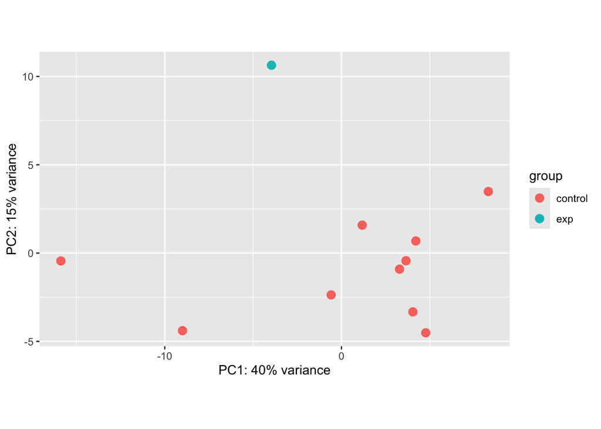

```r
#PCA
rld <- rlog(dds, blind=TRUE)
plotPCA(rld, intgroup="Group")
```

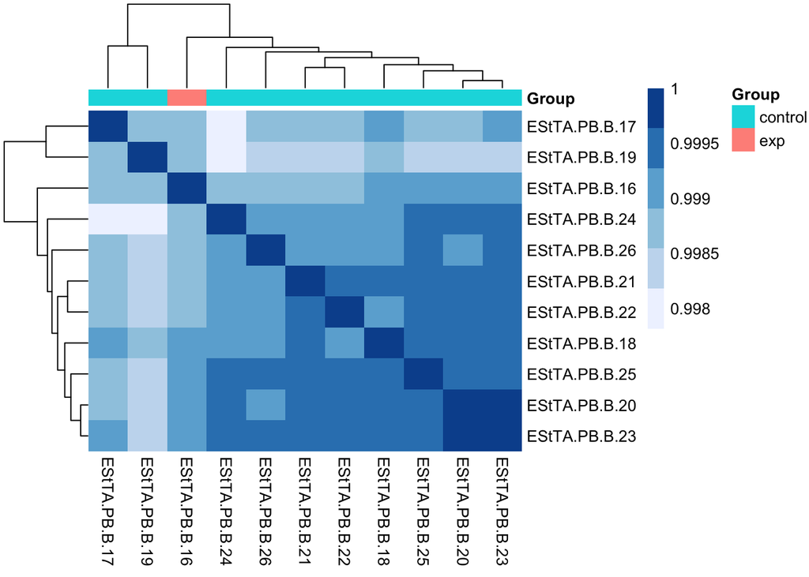

```r
#Heatmap
### Extract the rlog matrix from the object
rld_mat <- assay(rld)
### Compute pairwise correlation values
rld_cor <- cor(rld_mat)
## check the output of cor(), make note of the row names and column names
heat.colors <- RColorBrewer::brewer.pal(6, "Blues")
pheatmap(rld_cor, annotation = meta, color = heat.colors, border_color=NA, fontsize = 10,
         fontsize_row = 10, height=20)
```

### Dispersion Plot

The purpose of this plot is to see how well the data fits the DESEq2 model

```r
#Analysis
dds <- DESeq(dds)
```

```
## -- replacing outliers and refitting for 2717 genes
## -- DESeq argument 'minReplicatesForReplace' = 7
## -- original counts are preserved in counts(dds)
```

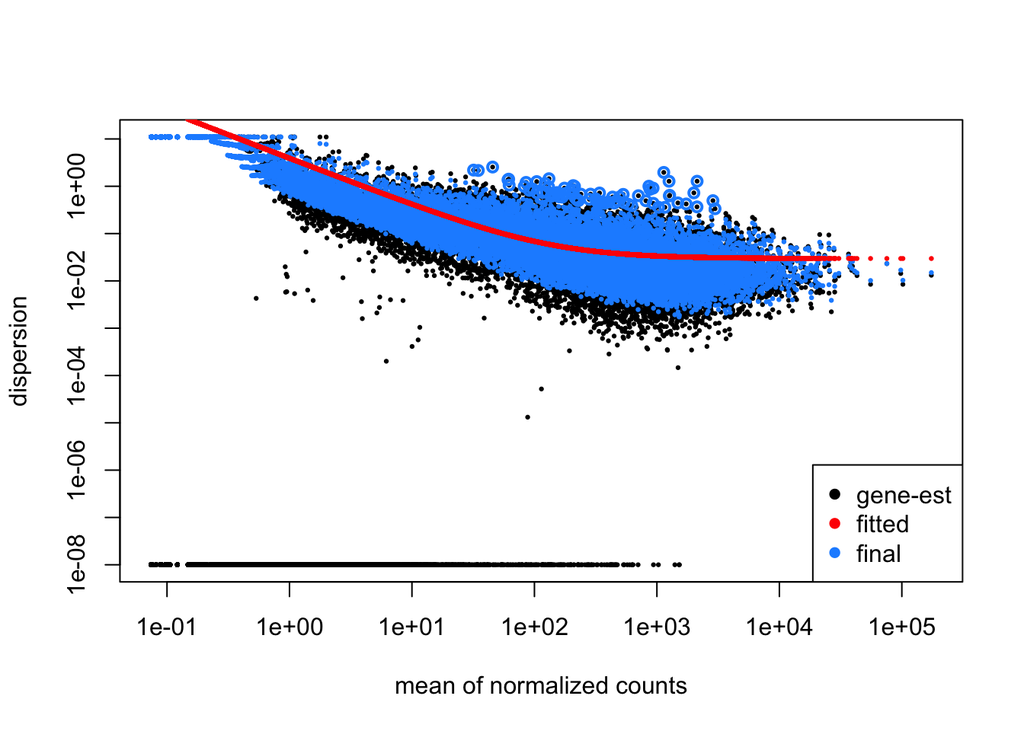

```r
#Check dispersion
plotDispEsts(dds)
```

### Wald Test

```r
#Wald test
contrast <- c("Group", "exp", "control")

#Extract results
res_table <- results(dds, contrast=contrast)
summary(res_table, alpha = 0.05)
```

```
##
## out of 18460 with nonzero total read count
## adjusted p-value < 0.05
## LFC > 0 (up)       : 229, 1.2%
## LFC < 0 (down)     : 144, 0.78%
## outliers [1]       : 0, 0%
## low counts [2]     : 5666, 31%
## (mean count < 11)
## [1] see 'cooksCutoff' argument of ?results
## [2] see 'independentFiltering' argument of ?results
```

### Results

```r
padj.cutoff <- 0.1

# Create a dataframe to simplify the res_table_try1 object
res_table_df <- res_table %>%
  data.frame() %>%
  rownames_to_column(var="gene")

#Add GTF info column to table
## Convert our GTF to a large data frame
###CONFIG: This is not in the repo and
gtf <- readGFF("../../data/gencode.vM25.annotation.gtf")

# Extract only the columns with ensembl gene names and gene symbols
gtf_names <- gtf %>% dplyr::select(gene_id, gene_name) %>%
  dplyr::distinct() %>%
  dplyr::rename(ensgene = gene_id, symbol = gene_name)

##merge gene symbols
res_table_df <- merge(gtf_names,res_table_df, by.x="ensgene", by.y="gene")

# Subset the dataframe to keep only significant genes
sig_genes <- res_table_df %>%
  dplyr::filter(padj < padj.cutoff)

#Exported results
##CONFIG Change the file names of the output!
write.table(res_table_df, file = "c16_res_table__df.tsv", sep = "\t", row.names=FALSE, col.names=TRUE, quote=FALSE)

write.table(sig_genes, file = "c16_sig_genes.tsv", sep = "\t", row.names=FALSE, col.names=TRUE, quote=FALSE)
```

```r
#Under construction!
```